# Practical Machine Learning - assignment

Kirsti Laurila

In the assignment we were supposed to build a model that predicts how people perform their exercise in gym. There are 5 classes to predict, A,B,C,D,E.

```r
library(caret)
library(ggplot2)
library(rpart)
library(randomForest)
library(gbm)
```

Then, we read in the data that should be located in working directory,

```r
train_data <- read.csv(file="pml-training.csv")
```

Next, we modify the training data. We won’t use timestamps and other metadata as predictos, so we first omit the 7 first columns containing this data. We will also include only the mean values of the measurements, so kurtosis, minimum, maximum, variance, standard deviation, amplitude and skewness variables will all be removed.

```r
col_names <- colnames(train_data)
remove_cols <- col_names[1:7]
remove_cols <- c(remove_cols,
grep("^kurtosis|^min|^max|^var|^stddev|^amplitude|skewness",
col_names, value=TRUE))
```

We then study, which columns have more than 50% of valus missing. These columns will be omitted as well. We finally end up with the following list of predictors to use.

```r
remove_too_many_nas<-colnames(train_data)[apply(train_data,2,function(x)
                                          length(which(is.na(x)))/length(x)>0.5)]
remove_cols=c(remove_too_many_nas,remove_cols)
#these are the column names to include
in_cols <- setdiff(col_names,remove_cols)
in_cols
```

```
##  [1] "roll_belt"            "pitch_belt"           "yaw_belt"
##  [4] "total_accel_belt"     "gyros_belt_x"         "gyros_belt_y"
##  [7] "gyros_belt_z"         "accel_belt_x"         "accel_belt_y"
## [10] "accel_belt_z"         "magnet_belt_x"        "magnet_belt_y"
## [13] "magnet_belt_z"        "roll_arm"             "pitch_arm"
## [16] "yaw_arm"              "total_accel_arm"      "gyros_arm_x"
## [19] "gyros_arm_y"          "gyros_arm_z"          "accel_arm_x"
## [22] "accel_arm_y"          "accel_arm_z"          "magnet_arm_x"
## [25] "magnet_arm_y"         "magnet_arm_z"         "roll_dumbbell"
## [28] "pitch_dumbbell"       "yaw_dumbbell"         "total_accel_dumbbell"
## [31] "gyros_dumbbell_x"     "gyros_dumbbell_y"     "gyros_dumbbell_z"
## [34] "accel_dumbbell_x"     "accel_dumbbell_y"     "accel_dumbbell_z"
## [37] "magnet_dumbbell_x"    "magnet_dumbbell_y"    "magnet_dumbbell_z"
## [40] "roll_forearm"         "pitch_forearm"        "yaw_forearm"
## [43] "total_accel_forearm"  "gyros_forearm_x"      "gyros_forearm_y"
## [46] "gyros_forearm_z"      "accel_forearm_x"      "accel_forearm_y"
## [49] "accel_forearm_z"      "magnet_forearm_x"     "magnet_forearm_y"
## [52] "magnet_forearm_z"     "classe"
```

Next, we need to select these columns and we divide the training data into training and testing sets. We include 60% of data in the training set. We see below how many rows in both training and testing sets have and also that both of them have 53 columns e.g. 52 predictors as the last column is the response variable, classe.

```r
train_data <- train_data[,in_cols]
in_train <- createDataPartition(y=train_data$classe, p=0.6, list=FALSE)
training <- train_data[in_train,]
testing <- train_data[-in_train,]
rbind(c("training", dim(training)),c("testing",dim(testing)))
```

```
##      [,1]       [,2]    [,3]
## [1,] "training" "11776" "53"
## [2,] "testing"  "7846"  "53"
```

Next, we want to study the dataset a bit. So we plot histograms of predictors. Here, only few of them are shown.

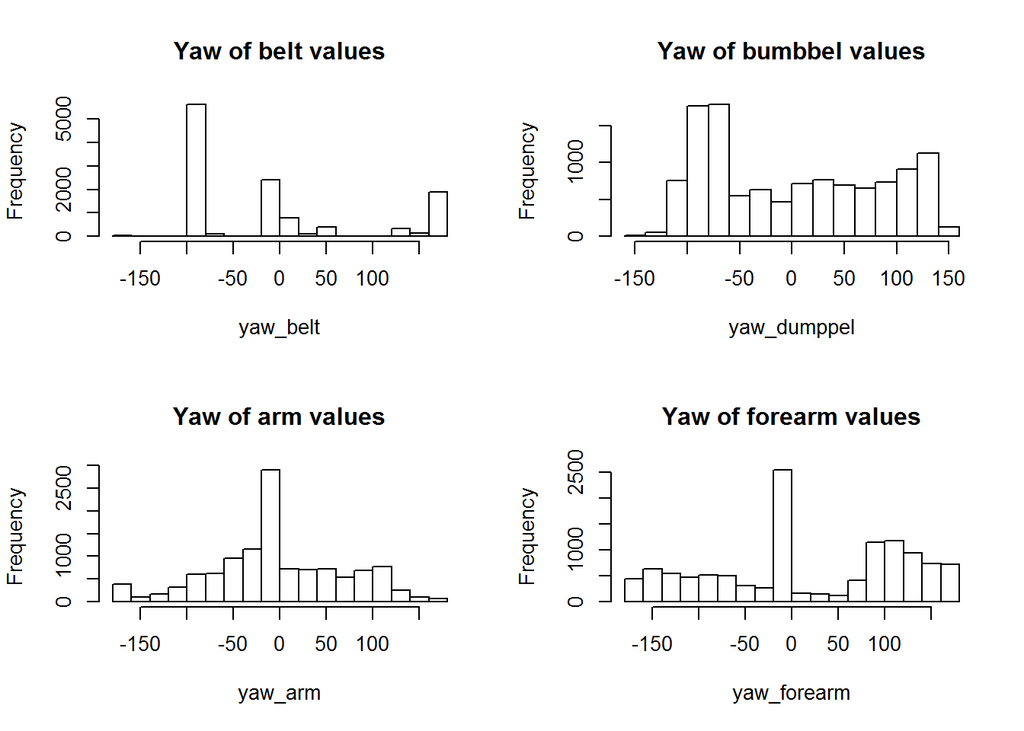

```r
par(mfrow=c(2,2))
hist(training$yaw_belt, 20, main="Yaw of belt values", xlab="yaw_belt")
hist(training$yaw_dumbbell, 20, main="Yaw of bumbbel values", xlab="yaw_dumppel")
hist(training$yaw_arm, 20, main="Yaw of arm values", xlab="yaw_arm")
hist(training$yaw_forearm, 20, main="Yaw of forearm values", xlab="yaw_forearm")
```

We see that the scale is similar in all these predictors but distributions differ. However, as we are using tree-based methods, preprocessing is not necessary and we don’t perform it.

```r
fitControl <- trainControl(## 10-fold CV
  method = "repeatedcv",
  number = 10,
  ## repeated ten times
  repeats = 10)

modFitRf<-train(classe~., method="rf",data=training, prox=TRUE,
                 trainControl=fitControl)


modFitRpart<-train(classe~., method="rpart",data=training)
```

We then check how accurate the models are. By using the testing set.

```r
accuracies <- c(length(which(predict(modFitRf, testing)==testing$classe))/length(testing$classe),
length(which(predict(modFitRpart, testing)==testing$classe))/length(testing$classe))
```

```r
1-accuracies[1]
```

```
## [1] 0.00254907
```

Finally, we want to see, which variables contribute to the predictions at most, by checkin variance importance. Here one can see the plot of the variance importance of each predictor.

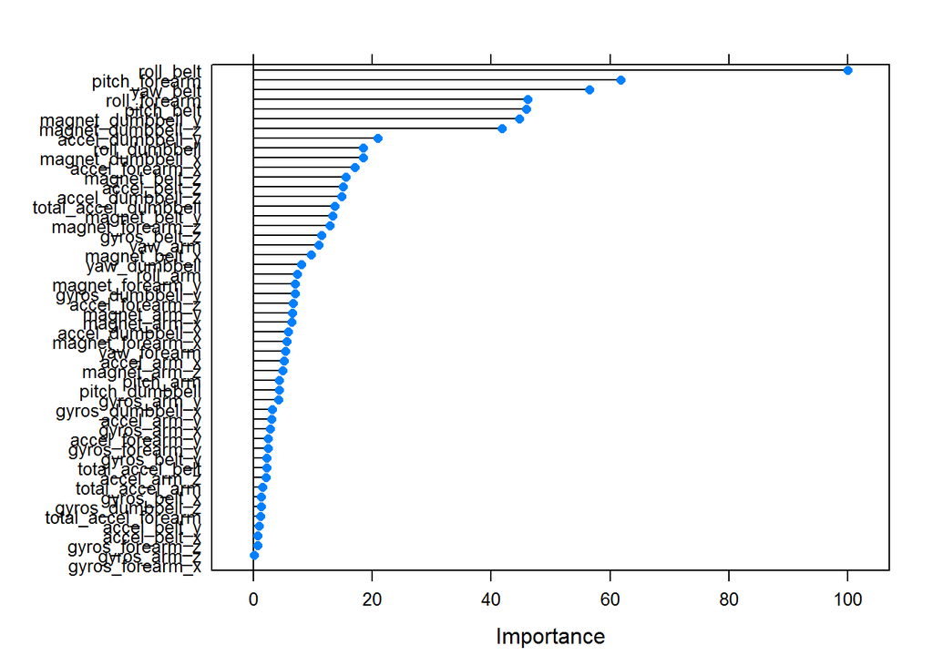

```r
varImportance <- varImp(modFitRf)
plot(varImportance)
```

```r
varImportance
```

```
## rf variable importance
##
##   only 20 most important variables shown (out of 52)
##
##                      Overall
## roll_belt            100.000
## pitch_forearm         61.832
## yaw_belt              56.579
## roll_forearm          46.154
## pitch_belt            45.875
## magnet_dumbbell_y     44.690
## magnet_dumbbell_z     41.848
## accel_dumbbell_y      20.895
## roll_dumbbell         18.511
## magnet_dumbbell_x     18.433
## accel_forearm_x       17.080
## magnet_belt_z         15.568
## accel_belt_z          15.066
## accel_dumbbell_z      14.831
## total_accel_dumbbell  13.640
## magnet_belt_y         13.380
## magnet_forearm_z      12.876
## gyros_belt_z          11.434
## yaw_arm               10.952
## magnet_belt_x          9.767
```